# qiime2R

J Bisanz

5/10/2018

# Background

qiime2R is intended to import qiime2 artifacts (.qza) directly into an R session while retaining the associated metadata and provenance. This tutorial shows an example of importing the main artifacts for a typical analysis (feature table, tree, and an ordination) and how those could be fed to phyloseq.

First we can start by loading the qiime2R and phyloseq packages.

```r
library(qiime2R)
```

Now we can import objects from the [moving pictures tutorial](https://docs.qiime2.org/2018.4/tutorials/moving-pictures/). They can be downloaded in the terminal as below:

```bash
wget https://data.qiime2.org/2018.4/tutorials/moving-pictures/sample_metadata.tsv
wget https://docs.qiime2.org/2018.4/data/tutorials/moving-pictures/table.qza
wget https://docs.qiime2.org/2018.4/data/tutorials/moving-pictures/rooted-tree.qza
wget https://docs.qiime2.org/2018.4/data/tutorials/moving-pictures/taxonomy.qza
```

```r
otus<-read_qza("~/QIIME2/mvpics/table.qza")
```

The imported data is stored as a named list wherein the actual data is appropriately named .$data

```r
otus$data[1:5,1:5] #show the first 5 samples and first 5 otus
```

```
##                                  L1S105 L1S140 L1S208 L1S257 L1S281
## 4b5eeb300368260019c1fbc7a3c718fc   2222      0      0      0      0
## fe30ff0f71a38a39cf1717ec2be3a2fc      5      0      0      0      0
## d29fe3c70564fc0f69f2c03e0d1e5561      0      0      0      0      0
## 868528ca947bc57b69ffdf83e6b73bae      0   2276   2156   1205   1772
## 154709e160e8cada6bfb21115acc80f5    812   1176    713    407    242
```

We can also inspect other information about the artifact:

```r
otus$uuid
```

```
## [1] "6a560288-898e-4c1d-92ac-dd8d7822dcc9"
```

```r
otus$type
```

```
## [1] "FeatureTable[Frequency]"
```

```r
otus$format
```

```
## [1] "BIOMV210DirFmt"
```

The provenance is avilable in `otus$provenance`; however, a future version will better be able to display this data in an intelligible format.

Now we can construct a phyloseq object by also pulling in the phylogenetic tree, taxonomy, and metadata

```r
library(phyloseq)
tree<-read_qza("~/QIIME2/mvpics/rooted-tree.qza")

taxonomy<-read_qza("~/QIIME2/mvpics/taxonomy.qza")
  tax_table<-do.call(rbind, strsplit(as.character(taxonomy$data$Taxon), "; "))
  colnames(tax_table)<-c("Kingdom","Phylum","Class","Order","Family","Genus","Species")
  rownames(tax_table)<-taxonomy$data$Feature.ID

metadata<-read.table("~/QIIME2/mvpics/sample-metadata.tsv", sep='\t', header=T, row.names=1, comment="")
metadata<-metadata[-1,]#remove the second line that specifies the data type

physeq<-phyloseq(otu_table(otus$data, taxa_are_rows = T), phy_tree(tree$data), tax_table(tax_table), sample_data(metadata))

physeq
```

```
## phyloseq-class experiment-level object
## otu_table()   OTU Table:         [ 759 taxa and 34 samples ]
## sample_data() Sample Data:       [ 34 samples by 10 sample variables ]
## tax_table()   Taxonomy Table:    [ 759 taxa by 7 taxonomic ranks ]
## phy_tree()    Phylogenetic Tree: [ 759 tips and 757 internal nodes ]
```

Now that the objects are in R-friendly forms, you can carry out analysis as per usual for example:

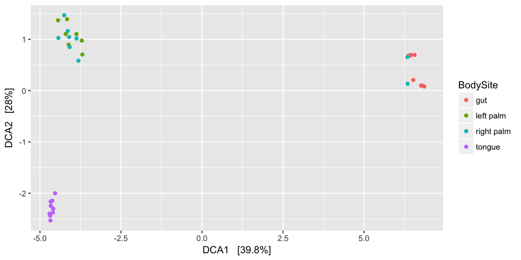

```r
plot_ordination(physeq, ordinate(physeq, "DCA"), type="samples", color="BodySite")
```

Or try using MicrobeR:

```r
#MicrobeR devtools::install_github("jbisanz/MicrobeR")
library(MicrobeR)
```

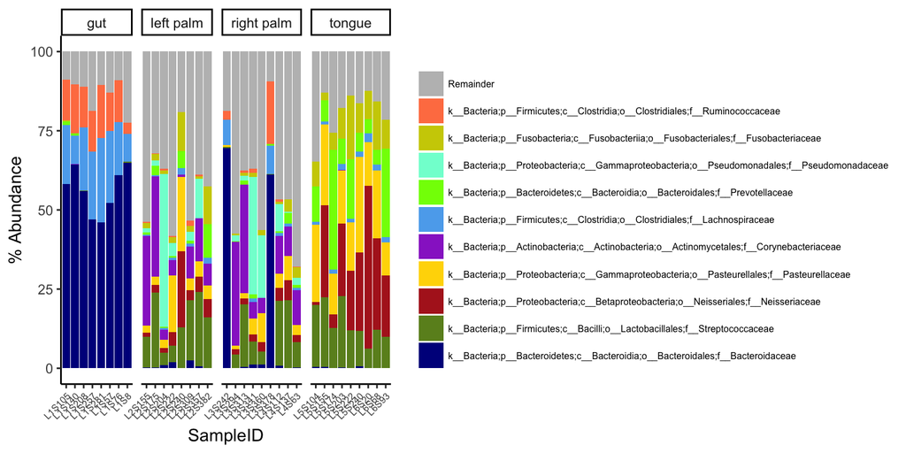

```r
Microbiome.Barplot(Summarize.Taxa(otus$data, as.data.frame(tax_table))$Family, metadata, CATEGORY="BodySite")
```

```r
PCoA("unweightedunifrac",  metadata, otus$data, tree$data, "BodySite")
```

```
## Subsampling feature table to 917 , currently has  759  taxa.
```

```
## ...sampled to 917 reads with 624 taxa
```

```
## Doing Unweighted UniFrac...
```

```
## Found more than one class "phylo" in cache; using the first, from namespace 'phyloseq'
```

```
## Also defined by 'treeio'
```

```
## Found more than one class "phylo" in cache; using the first, from namespace 'phyloseq'
```

```
## Also defined by 'treeio'
```

```
## Found more than one class "phylo" in cache; using the first, from namespace 'phyloseq'
```

```
## Also defined by 'treeio'
```

```
## Found more than one class "phylo" in cache; using the first, from namespace 'phyloseq'
```

```
## Also defined by 'treeio'
```

```
## Calculating ADONIS for BodySite
```

```
## [1] "BodySite-> ADONIS P=0.027 R2=0.165"
```

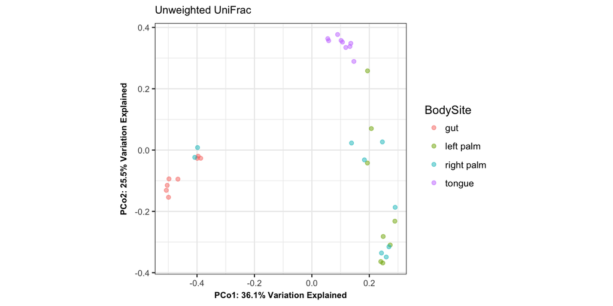

Please report any issues or send suggestions to jordan.bisanz@gmail.com.